# ADA Aquire and Analyze

AJ Eckmann

April 1, 2020

## Introduction

The question that I am trying to solve is, what factors (that we know pre-game), can we use to better predict the outcome of a NCAA Basketball game. As a huge college basketball fan, I frequently hear “defense wins championships” or “the best free throw shooting team wins”, and I thought it would be really cool to see which of these stats have a significant impact that we can actually identify in a model.

The data from sports-reference is game by game statistics for each team in division 1 basketball during the 2019-2020 season. The data from KenPom is efficiency data for all 353 division 1 teams for the 2019-2020 season.

The original data from sports-reference is 1 row per game played, and listed stats such as FG, FGA, 3P, 3PA, etc for that specific game. Using Vlookups and AverageIfs in Excel, I used the game by game data to extract season averages for each team. Next, I created a new table with 1 row for each team for each game. The columns are: Team, Opponent, PTS (how many points they scored that game), Home (0 for away, 0.5 for neutral, 1 for home). After this, I appended the season averages for both the Team and Opponent, as well as the Ken Pom efficiency stats for both of these teams.

Below is where I scraped/reformatted the KenPom dataset. I also printed the first few rows so you can get an idea of what it looks like.

## Data

```r
kenpom <- read_html("https://kenpom.com/index.php?y=2020")
temp <- kenpom  %>%
  html_table(header = FALSE)

## Reformat the names

temp[[1]][2,][7] = "AdjORk"
temp[[1]][2,][9] = "AdjDRk"
temp[[1]][2,][11] = "AdjTRk"
temp[[1]][2,][13] = "LuckRk"
temp[[1]][2,][14] = "SOSAdjEM"
temp[[1]][2,][15] = "SOSAdjEM-Rk"
temp[[1]][2,][16] = "SOSOppO"
temp[[1]][2,][17] = "SOSOppORk"
temp[[1]][2,][18] = "SOSOppD"
temp[[1]][2,][19] = "SOSOppDRk"
temp[[1]][2,][20] = "NCSOSAdjEM"
temp[[1]][2,][21] = "NCSOSAdjEMRk"


temp <- temp %>%
  map(~ set_names(.x, nm = .x[2,]) %>% slice(-c(1, 2)))

temp <- as.data.table(temp, keep.rownames=FALSE)

t <- c()
for (j in 1:nrow(temp)){
  if (temp[j,1] == "Rk" ) {t <- c(t,as.numeric(j))}
  else if (!(temp[j,1] > 0)) {t <- c(t,as.numeric(j))}}

temp <- temp[-t, ]
temp$wins <- 0
temp$losses <- 0

for (j in 1:nrow(temp)){
  spl <- str_split(temp[j][,4],"-")
  temp[j][,22] <- as.numeric(spl[[1]][1])
  temp[j][,23] <- as.numeric(spl[[1]][2])
  temp[j][,4] = paste0("'", as.character(temp[j][,4]))}

for(i in 1:nrow(temp)){
  a = length(unlist(strsplit(temp[i,][[2]], " ")))
  top = unlist(strsplit(temp[i,][[2]], " "))[-a]
  seed = unlist(strsplit(temp[i,][[2]], " "))[a]
  if (seed %in% c(1,2,3,4,5,6,7,8,9,10,11,12,13,14,15,16)){
  temp[i,][[2]] = str_c(top, collapse = " ")}}

temp = temp

write.csv(temp, "C:/Users/ajeck/Documents/ADA/ADA-AandA/2020kp2.csv", row.names = FALSE)

head(temp)
```

```
##    Rk             Team Conf   W.L  AdjEM  AdjO AdjORk AdjD AdjDRk AdjT AdjTRk
## 1:  1        Kansas 1*  B12 '28-3 +30.23 115.8      8 85.5      2 67.3    233
## 2:  2       Gonzaga 1*  WCC '31-2 +26.95 121.3      1 94.4     43 71.9     35
## 3:  3        Baylor 1*  B12 '26-4 +25.49 113.5     17 88.1      4 66.2    277
## 4:  4        Dayton 1*  A10 '29-2 +24.93 119.1      2 94.1     38 67.6    220
## 5:  5          Duke 3*  ACC '25-6 +24.62 115.7      9 91.1     12 72.0     34
## 6:  6 San Diego St. 2*  MWC '30-2 +24.48 115.1     11 90.6     10 64.6    332
##     Luck LuckRk SOSAdjEM SOSAdjEM.Rk SOSOppO SOSOppORk SOSOppD SOSOppDRk
## 1: +.040     79   +12.66           2   107.4        26    94.7         1
## 2: +.050     50    +2.42         109   103.5       115   101.0        99
## 3: +.016    144   +10.20          27   106.4        39    96.2        11
## 4: +.002    180    +2.74         105   104.1       103   101.3       105
## 5: -.009    209    +7.28          54   106.0        53    98.7        58
## 6: -.008    204    +2.98         101   105.3        76   102.3       136
##    NCSOSAdjEM NCSOSAdjEMRk wins losses
## 1:      +9.58           10   28      3
## 2:      -2.09          245   31      2
## 3:      +1.38          132   26      4
## 4:      -0.74          203   29      2
## 5:      +2.60           85   25      6
## 6:      -1.80          239   30      2
```

For reference, there are 353 Division 1 basketball teams, and there is one row per team in the KenPom dataset. A lot of the KenPom set is based on rankings, which I don’t want to use in this regression, instead I will use the raw numbers that are continuous (these are called ratings). The four main ratings that I use in my models are:

AdjEM - overall rating, higher score is better, (calculated as AdjO - AdjD), this causes multicollinearity issues if all 3 are included in a model,

AdjO - offensive rating, as a factor of points per 100 possessions, a higher score indicates a better offense,

AdjD - defensive rating, as a factor of points per 100 possessions, a lower score indicates a better defense,

AdjT - Tempo rating, ie how fast the team plays, a higher score means a faster tempo.

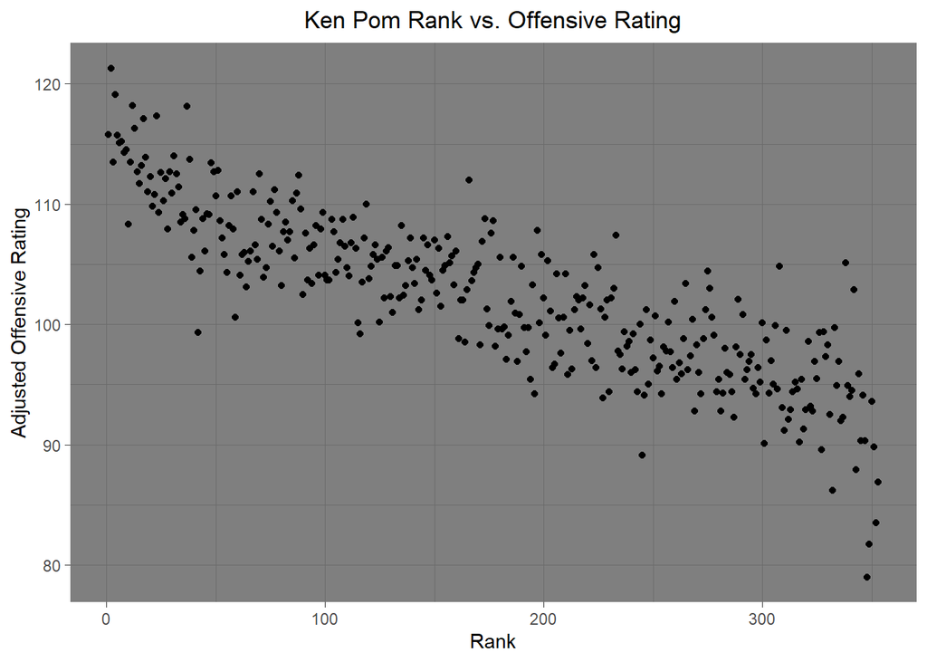

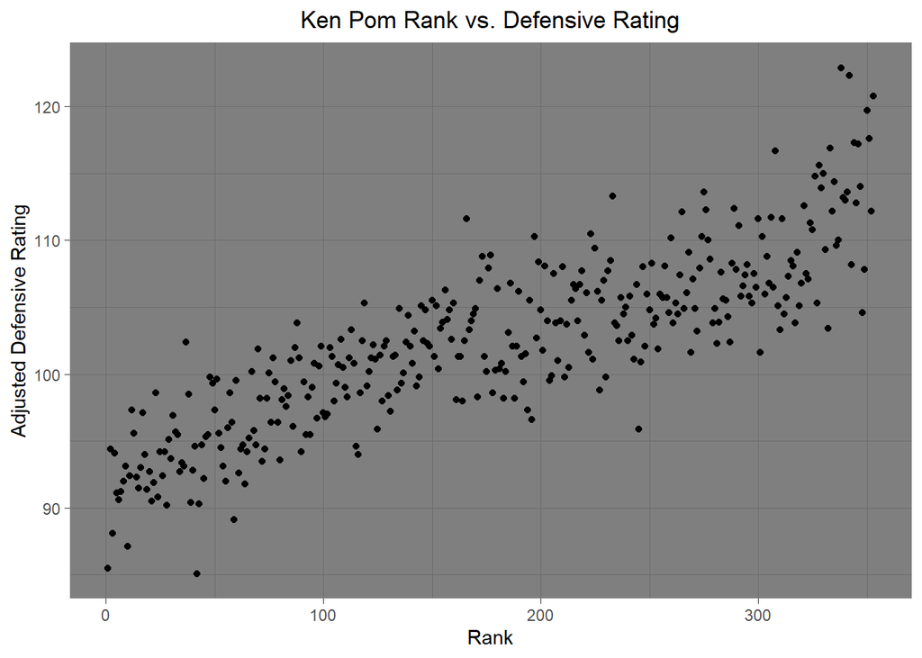

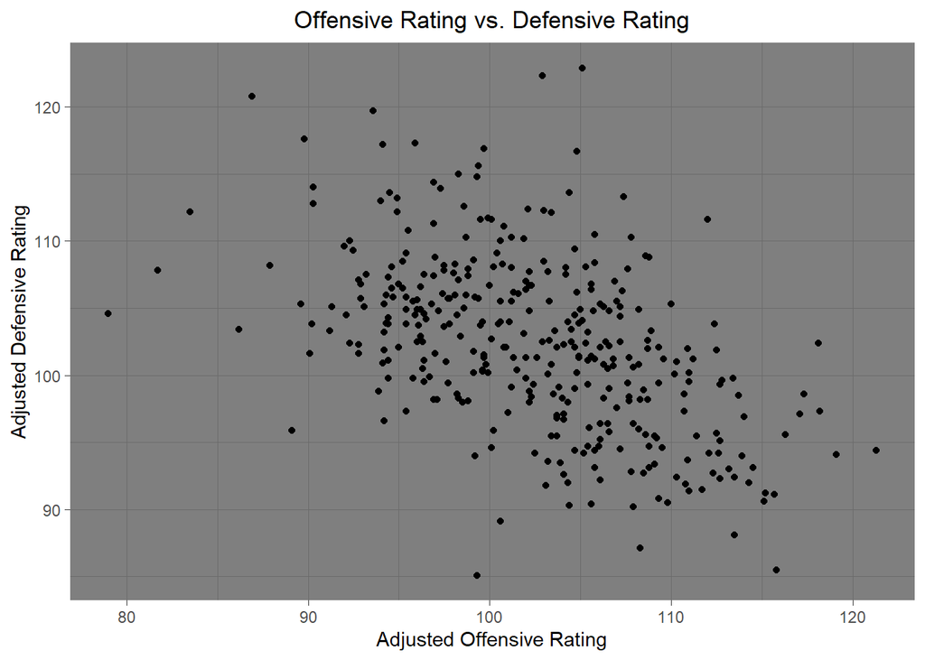

In the plots below, I plotted the KenPom Rankings against the number of wins that the team had in the 2020 season as some further EDA. As can be seen in the plots, it appears that overall rank, high AdjO and low AdjD are all associated with more wins.

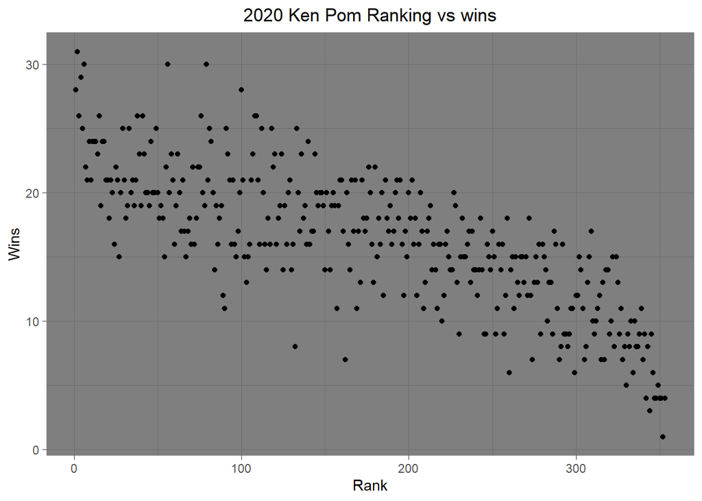

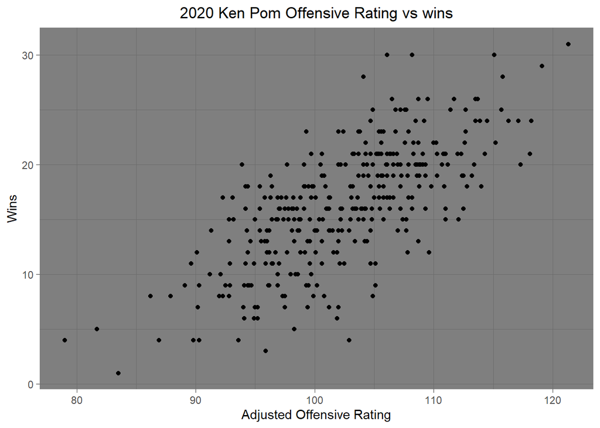

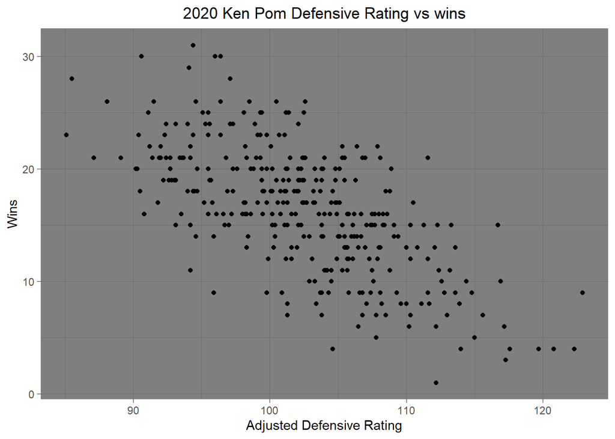

### Reading in new data

In order to perform my analysis, I pulled in the offensive and defensive season averages for each team that I created in Excel. To get these tables I pulled boxscore data from all of the games last season from basketballreference.com using excel, then I made two new CSVs (OFF and DEF) and used sumif / averageif statements to calculate each teams season averages from last year. These two tables (off_avg and def_avg) hold the same metrics, but off_avg is what the team averages in each of these categories per game, while def_avg is what this team gives up to their opponents in each of these categories per game. These tables are basically “FOR” (OFF) and “AGAINST” (DEF) averages, but I had already done the work using OFF/DEF by the time I did the write up so I will use that terminology throughout.

Next, I took the KenPom output from earlier and reformatted the naming convention to match the spelling/names from the def_avg and off_avg csvs from basketball reference (I just used Vlookup in Excel). I was then able to merge these three data sets on “TEAM”, to create a table of 353 rows (teams) and 69 variables (statistics/efficiency metrics).

I did a little more EDA on the new dataset just to ensure that the KenPom efficiency metrics were actually correlated with the season averages that I pulled, which they were. As can be seen below, higher AdjO is associated with more points scored, lower AdjD is associated with fewer points given up and AdjT is associated with more points scored, just as we would expect.

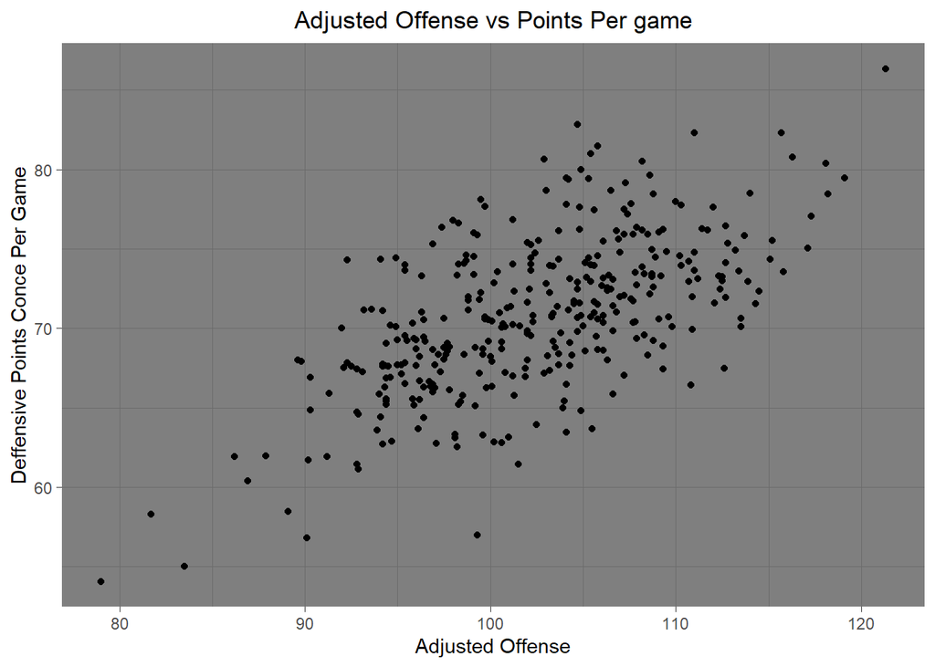

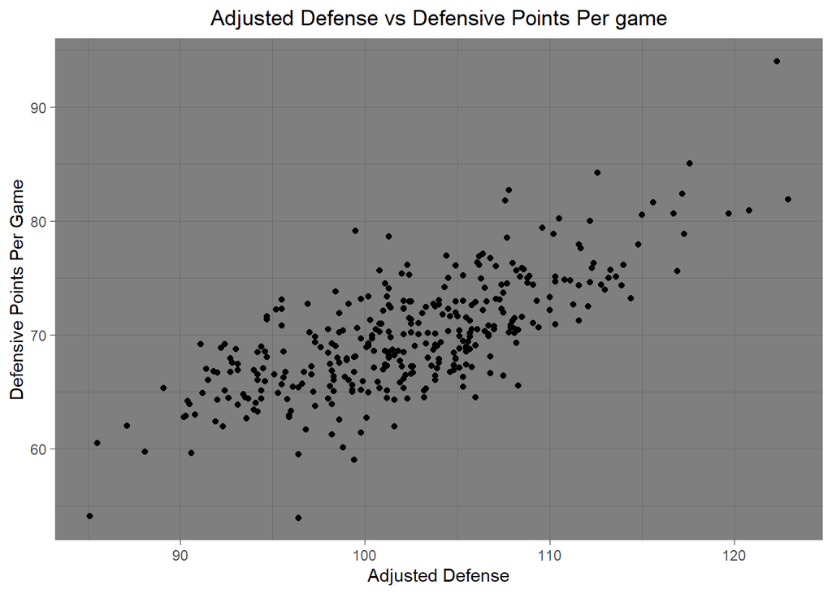

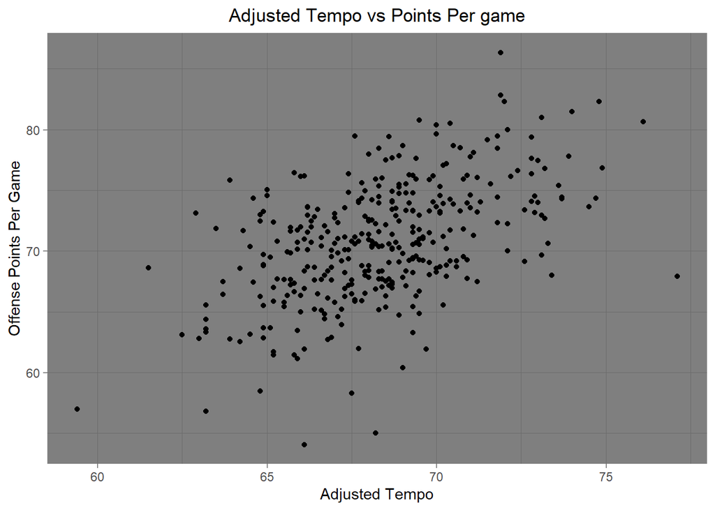

## Methods

The main method that I used in building my model was simple linear regression. I also tried using logistic regression with a binary W/L response, but these results were not near as successful as linear regression. To do this linear regression, I used game by game data that I pulled from basketball reference. Due to my lack of expertise in R, and the ease (my familiarity) of Vlookups in Excel I did some data manipulation of the boxscore data in excel before pulling it into R. First, I narrowed down the box score data that I had used for the season averages tables (that had game-level stats) and cut it to 6 variables (Date, Team, Opp, Result, PTS, Home). In this re-formatted datatable, there are 2 rows for each game (one row for each instance of Team v. Opp). In each row, the Pts and Home variables are with respect to Team (not Opp). The Home variable is 1 for home, 0.5 for nuetral and 0 for away.

Entry 1: Date = 11/25/2020, Team = Duke, Opp = Florida, PTS = 83, Home = 0

From here I appended the “FOR” (OFF) stats for Duke, and “AGAINST” (DEF) stats for Florida for entry 1 and vice versa for entry 2. I designed the data this way intentially, because I want to create a model that will predict PTS (not just binary W/L), so we can take into account margin. From the way that this model is set up, we are using PTS as the response variable (which is how many points that team scored in that specific matchup - ie Duke scoring 83 against Florida on 11/25/2020), and using the KenPom/season averages of both the TEAM and OPP to try to create a model to predict how many points they would score in a specific matchup, then we can compare PTS predictions and turn this into W/L. The idea is that the KenPom/Season Average stats will be available for us when we are predicting the points scored pre-game, so we want to regress on these averages/efficiency metrics, not the box score stats from that day (that we would have no way of knowing ahead of time).

Below is the full linear model, minus the team, opponent, result, and a few stats that would cause multicollinearity issues if included (For example, you can’t have FT made, FT attemps and FT % because they are factors of one another). Additionally, it is important to note that I used TEAM and OPP to pull in the season averages and efficiency metrics, for those particular teams (for each row) so there is no reason to keep Team or Opp in the model. Additionally, I coded the data so that all the “FOR” (OFF) stats start with “O.” and all the “AGAINST” (DEF) stats start with “D.”. To further explain, in any given row of our data the “O.FG” variable is the season average “made field goals” for the team in the TEAM column. The “D.FG” variable is the season average “conceded field goals” for the team in the OPP column. The “O.FG” variable gives us an idea of how many field goals the team of interest ‘TEAM’ (who the PTS column that we are regressing on is associated with) scores on average, while the “D.FG” variable gives us an idea of how many field goals their opponent usually gives up. Both of these are useful in predicting how many points ‘TEAM’ will score.

```r
#Full Linear Model
full_model <- lm(PTS ~ . - Date - TEAM - OPP - Result - O.AdjEM - D.AdjEM - O.3P - O.3PA - D.3PA - O.2P - O.FT - D.3P - D.2P - D.FT - O.TRB - D.TRB, data = games)
summary(full_model)
```

```
##
## Call:
## lm(formula = PTS ~ . - Date - TEAM - OPP - Result - O.AdjEM -
##     D.AdjEM - O.3P - O.3PA - D.3PA - O.2P - O.FT - D.3P - D.2P -
##     D.FT - O.TRB - D.TRB, data = games)
##
## Residuals:
##     Min      1Q  Median      3Q     Max
## -30.836  -6.202  -0.242   6.041  43.883
##
## Coefficients:
##               Estimate Std. Error t value Pr(>|t|)
## (Intercept) -1.460e+02  2.909e+01  -5.020 5.27e-07 ***
## O.FG         7.515e-01  1.262e+00   0.596   0.5515
## O.FGA        1.283e-01  3.795e-01   0.338   0.7353
## O.FGP       -5.287e+00  5.498e+01  -0.096   0.9234
## O.2PA       -1.323e-01  2.227e-01  -0.594   0.5524
## O.2PP       -1.972e+01  2.391e+01  -0.825   0.4096
## O.3PP       -1.218e+00  1.373e+01  -0.089   0.9293
## O.FTA        2.370e-01  3.289e-01   0.720   0.4713
## O.FTP        8.418e-01  8.779e+00   0.096   0.9236
## O.PTS       -2.012e-02  4.603e-01  -0.044   0.9651
## O.ORB       -2.846e-01  1.530e-01  -1.860   0.0629 .
## O.DRB       -3.480e-02  9.730e-02  -0.358   0.7206
## O.AST        5.929e-03  8.307e-02   0.071   0.9431
## O.STL       -1.236e-01  1.351e-01  -0.915   0.3603
## O.BLK        5.325e-02  1.232e-01   0.432   0.6654
## O.TOV        2.241e-01  1.436e-01   1.560   0.1187
## O.PF        -1.791e-02  7.024e-02  -0.255   0.7988
## D.FG         9.070e-01  1.328e+00   0.683   0.4947
## D.FGA       -1.605e-01  3.934e-01  -0.408   0.6834
## D.FGP       -3.967e+01  5.663e+01  -0.701   0.4836
## D.2PA       -2.069e-02  2.087e-01  -0.099   0.9210
## D.2PP       -1.191e+01  2.131e+01  -0.559   0.5764
## D.3PP       -5.519e+00  1.443e+01  -0.382   0.7021
## D.FTA        7.013e-02  3.320e-01   0.211   0.8327
## D.FTP       -8.381e-01  7.972e+00  -0.105   0.9163
## D.PTS        2.292e-01  4.551e-01   0.504   0.6146
## D.ORB       -3.631e-01  1.753e-01  -2.071   0.0384 *
## D.DRB        6.517e-03  8.844e-02   0.074   0.9413
## D.AST       -1.321e-02  1.012e-01  -0.130   0.8962
## D.STL       -2.869e-02  1.554e-01  -0.185   0.8535
## D.BLK       -3.139e-03  1.815e-01  -0.017   0.9862
## D.TOV        2.299e-01  1.216e-01   1.890   0.0588 .
## D.PF         2.280e-02  7.677e-02   0.297   0.7665
## O.AdjO       6.472e-01  4.186e-02  15.464  < 2e-16 ***
## O.AdjD      -5.344e-02  3.035e-02  -1.761   0.0783 .
## O.AdjT       6.389e-01  1.117e-01   5.720 1.09e-08 ***
## D.AdjO      -5.745e-02  2.827e-02  -2.033   0.0421 *
## D.AdjD       5.915e-01  4.308e-02  13.731  < 2e-16 ***
## D.AdjT       5.803e-01  1.108e-01   5.238 1.66e-07 ***
## HOME         3.454e+00  2.041e-01  16.918  < 2e-16 ***
## ---
## Signif. codes:  0 '***' 0.001 '**' 0.01 '*' 0.05 '.' 0.1 ' ' 1
##
## Residual standard error: 9.261 on 9446 degrees of freedom
## Multiple R-squared:  0.3864, Adjusted R-squared:  0.3838
## F-statistic: 152.5 on 39 and 9446 DF,  p-value: < 2.2e-16
```

I then experimented with many condensed forms of this model because, as shown above, many of the p-values in the full model are very high. I didn’t include all these model outputs in the report for sake of space, but they are all in the RMD file.

After playing around with the models for a while, I ran a couple of the better models through the stepAIC function in R. Below is one example of how the AIC backwards selection works from the base model ‘fit’. As is shown below, my model here was improved by removing ‘D.TOV’, which I previously had in the model.

```r
fit <- lm(PTS ~ HOME + O.PTS + D.PTS + D.TOV + O.AdjO + O.AdjD + O.AdjT + D.AdjO + D.AdjD + D.AdjT, data=games)
step <- stepAIC(fit, direction="both")
```

```
## Start:  AIC=42228.69
## PTS ~ HOME + O.PTS + D.PTS + D.TOV + O.AdjO + O.AdjD + O.AdjT +
##     D.AdjO + D.AdjD + D.AdjT
##
##          Df Sum of Sq    RSS   AIC
## - D.TOV   1        12 811755 42227
## <none>                811742 42229
## - O.AdjD  1       396 812139 42231
## - D.AdjO  1       610 812352 42234
## - O.PTS   1      1215 812957 42241
## - D.PTS   1      2090 813832 42251
## - D.AdjT  1      9449 821191 42336
## - O.AdjT  1     19919 831662 42457
## - D.AdjD  1     21683 833426 42477
## - HOME    1     25616 837358 42521
## - O.AdjO  1     32227 843969 42596
##
## Step:  AIC=42226.83
## PTS ~ HOME + O.PTS + D.PTS + O.AdjO + O.AdjD + O.AdjT + D.AdjO +
##     D.AdjD + D.AdjT
##
##          Df Sum of Sq    RSS   AIC
## <none>                811755 42227
## + D.TOV   1        12 811742 42229
## - O.AdjD  1       403 812158 42230
## - D.AdjO  1       725 812479 42233
## - O.PTS   1      1261 813016 42240
## - D.PTS   1      2089 813844 42249
## - D.AdjT  1     11303 823058 42356
## - O.AdjT  1     19907 831662 42455
## - D.AdjD  1     21866 833621 42477
## - HOME    1     25661 837415 42520
## - O.AdjO  1     32590 844345 42598
```

```r
step$anova # display results
```

```
## Stepwise Model Path
## Analysis of Deviance Table
##
## Initial Model:
## PTS ~ HOME + O.PTS + D.PTS + D.TOV + O.AdjO + O.AdjD + O.AdjT +
##     D.AdjO + D.AdjD + D.AdjT
##
## Final Model:
## PTS ~ HOME + O.PTS + D.PTS + O.AdjO + O.AdjD + O.AdjT + D.AdjO +
##     D.AdjD + D.AdjT
##
##
##      Step Df Deviance Resid. Df Resid. Dev      AIC
## 1                          9475   811742.4 42228.69
## 2 - D.TOV  1 12.36697      9476   811754.8 42226.83
```

In this next code block I ran a backwards selection AIC function on the (nearly) full-model. This is how I came up with my final model. I didn’t print the full output and commented the code out for sake of space, but the back_selec model below was the result.

```r
#fit <- lm(PTS ~ . - Date - TEAM - OPP - Result - O.3P - O.2P - O.FT - D.3P - D.2P - D.FT - O.TRB - D.TRB, data=games)
#step <- stepAIC(fit, direction="both")
#step$anova # display results

### Steps above do backwards selection to optimize AIC. This process is slow, and also prints out every step which takes up a lot of space.
### I ran this once and then just copy and pasted the output so I didn't have to reprint it in the final report. The output is below:
#PTS ~ O.FG + O.2PA + O.2PP + O.FTA + D.FG + D.FGP + D.FTA + D.PTS + D.ORB + D.TOV + O.AdjEM + O.AdjD + O.AdjT + D.AdjO + D.AdjD + D.AdjT + HOME

back_selec <- lm(PTS ~ O.FG + O.2PA + O.2PP + O.FTA + D.FG + D.FGP + D.FTA + D.PTS + D.ORB + D.TOV + O.AdjEM + O.AdjD + O.AdjT + D.AdjO + D.AdjD +
                               D.AdjT + HOME, data = games)

summary(back_selec)
```

```
##
## Call:
## lm(formula = PTS ~ O.FG + O.2PA + O.2PP + O.FTA + D.FG + D.FGP +
##     D.FTA + D.PTS + D.ORB + D.TOV + O.AdjEM + O.AdjD + O.AdjT +
##     D.AdjO + D.AdjD + D.AdjT + HOME, data = games)
##
## Residuals:
##     Min      1Q  Median      3Q     Max
## -30.834  -6.191  -0.249   6.045  44.193
##
## Coefficients:
##               Estimate Std. Error t value Pr(>|t|)
## (Intercept) -158.14327    9.24380 -17.108  < 2e-16 ***
## O.FG           0.55785    0.15634   3.568 0.000361 ***
## O.2PA         -0.12623    0.04618  -2.733 0.006286 **
## O.2PP        -16.55009    6.00309  -2.757 0.005846 **
## O.FTA          0.13807    0.05062   2.728 0.006387 **
## D.FG           0.72610    0.29982   2.422 0.015462 *
## D.FGP        -39.95169   14.26815  -2.800 0.005120 **
## D.FTA          0.13484    0.07920   1.703 0.088667 .
## D.PTS          0.18789    0.09223   2.037 0.041652 *
## D.ORB         -0.43346    0.15641  -2.771 0.005593 **
## D.TOV          0.27811    0.11159   2.492 0.012711 *
## O.AdjEM        0.63916    0.02922  21.877  < 2e-16 ***
## O.AdjD         0.60094    0.04055  14.818  < 2e-16 ***
## O.AdjT         0.79421    0.06135  12.946  < 2e-16 ***
## D.AdjO        -0.05157    0.01868  -2.761 0.005774 **
## D.AdjD         0.58196    0.03638  15.997  < 2e-16 ***
## D.AdjT         0.53407    0.09967   5.359 8.58e-08 ***
## HOME           3.46794    0.20350  17.042  < 2e-16 ***
## ---
## Signif. codes:  0 '***' 0.001 '**' 0.01 '*' 0.05 '.' 0.1 ' ' 1
##
## Residual standard error: 9.253 on 9468 degrees of freedom
## Multiple R-squared:  0.386,  Adjusted R-squared:  0.3849
## F-statistic: 350.1 on 17 and 9468 DF,  p-value: < 2.2e-16
```

## Results

After finalizing my model, I first ran a k-fold cross validation (for the sake of legibility I only did 3 folds below, but I looked at all the way up to 10 in my RMD before finalizing the report). As can be seen in the plot below, it seems like our model did a pretty good job of predicting how many points would be scored, even in a 3-fold cross validation.

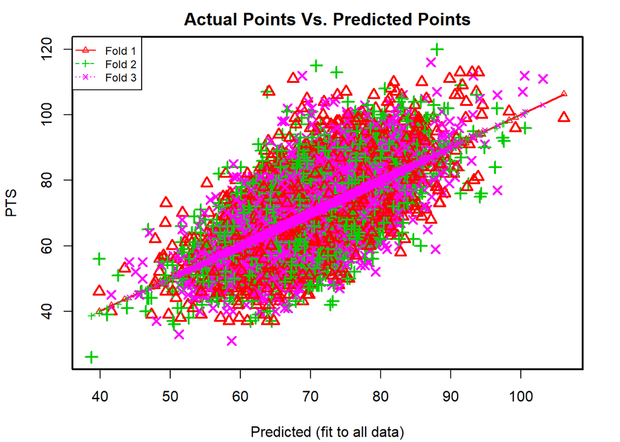

```r
# K-fold cross-validation
cv.lm(games, final_lin, m=3, printit = FALSE, dots = FALSE, main="Actual Points Vs. Predicted Points") # 3 fold cross-validation
```

Next I wanted to actually see how accurate my model was at predicting a winner. I pulled out a testing set (the first 772 entries, which took place in March), and used all of the other data to train a model.

```r
test = games[1:772,] # all games in March
train = games[773:nrow(games),] # all other games

#final model as described in the Model section above
train_lin <- lm(PTS ~ O.FG + O.2PA + O.2PP + O.FTA + D.FG + D.FGP + D.FTA + D.PTS + D.ORB + D.TOV + O.AdjEM + O.AdjD + O.AdjT + D.AdjO + D.AdjD +
                               D.AdjT + HOME, data = train)

#create a prediction column which is my prediction for the 'TEAM'
test$pred <- predict.lm(train_lin,test)

#Need some way to get the "Opp" score prediction on the same line so I can predict W/L, not just score
#initialize 2 new variables
test$pred2 <- 4
test$pred2 <- 5

#The way the data is set up, the two teams that played are stacked on top of each other. For example, if Duke and Florida played, their predictions would be in two different rows one where (TEAM = Duke and Opp = Floria) that predicts the Duke score and one where (TEAM = Florida and Opp = Duke) that predicts the Florida score. These rows will be 1 and 2 in the data set, and the next game will be rows 3 and 4, and so on.

#Goes through and looks at the prediction in the row below and sets it equal to pred2
for(i in 1:nrow(test)){
  if(i == 1){
    test$pred2[i] = 0
  }
  else{
  test$pred2[i] <- test$pred[i-1]}}

#Goes through and looks at the prediction in the row above and sets it equal to pred3
for(i in 1:nrow(test)){
  if(i == nrow(test)){
    test$pred3[nrow(test)] = 0
  }
  else{
  test$pred3[i] <- test$pred[i+1]}}

#Now we just need to sort out it their opponent is in the row above or the row below, that way we know wheter to use pred2 or pred3
test$oppPre <- 6
for(i in 1:nrow(test)){
  if(i %% 2 == 0){
    test$oppPre[i] = test$pred2[i]
  }
  else{
   test$oppPre[i] = test$pred3[i]
  }
}

#Now we predict win or lose based on our prediction compared to the prediction for the opponent
test$preW <- 7
for(i in 1:nrow(test)){
  if(as.numeric(test$oppPre[i]) > as.numeric(test$pred[i])){test$preW[i] = 0}
  else{test$preW[i] = 1}}

#Compare the W/L prediction to if they actually won or lost
test$right <- 0
for(i in 1:nrow(test)){
  if(test$Result[i] ==  "W"){
    if(test$preW[i] == 1){
      test$right[i] = 1
    }
  }
  if(test$Result[i] == "L"){
    if(test$preW[i] == 0){
      test$right[i] = 1}
  }
}

#Mean of this will test us how often we predicted correctly
mean(test$right)
```

```
## [1] 0.7357513
```

As can be shown from the output above, in the 386 (772/2 rows per game) March games in 2020, our model predicted the correct winner 73.6% of the time. In a sport with as much variability as basketball, where we see big upsets all the time, this is a pretty accurate model.

Next I designed a function that will take in two teams (team1 and team2) and who the home team is, and returns a data frame of a score prediction. I have not printed out how I created the function in the report output for the sake of space, but it is in the RMD file. Here is an example of how the function works:

In this example I am predicting that a game between Duke and Kansas (held at Duke) will result in a 72.9 - 71.9 victory for Kansas.

```r
## Built Predictor
team1 = "Duke"
team2 = "Kansas"
home_te1 = 1 #1 means team1 is at home, 0 would mean team1 is away

predictor(team1, team2, home_te1)
```

```
##      Duke   Kansas
## 1 71.8966 72.86243
```

## Future Directions

One thing that could be done to further this predictor would be associating the score predictions into a probability of victory. This would be cool to look at when filling out a March Madness bracket, because while the model may not predict the big underdog to win outright, it might give them a 40% chance, which could be used to determine if this was worth the risk of taking the underdog. I know that ESPN reports out what % of people pick each particular team, so we could use this information to help determine if it is worth the risk to take a big underdog with a decent chance of winning in order to get a one-up in your pool.

Another cool future direction would be to pull in today’s games from basketball reference and automate a predictor that could just scrape the games and come up with a prediction for each game in seconds.